# Cervical Cancer Screening Among Women in Zimbabwe

Zimbabwe Demographic and Health Survey Analysis 2015

Guillaume EMS

2025-12-10

**Contents**

- Introduction
  - DHS data used in this report
  - Selected variables
- Data Visualization
  - Cervical cancer awareness
  - Screening uptake
  - Screening recency
  - Screening by age group
- Conclusions
- Limitations

## Introduction

Cervical cancer is a major public health problem in low- and middle-income countries, where nearly 90% of cervical cancer deaths occur, despite the disease being largely preventable through screening ([WHO. Cervical cancer – Key facts](https://www.who.int/news-room/fact-sheets/detail/cervical-cancer)). In sub-Saharan Africa, it remains one of the leading causes of cancer mortality among women ([IARC/WHO. Global Cancer Observatory – Cervical Cancer](https://www.who.int/news-room/fact-sheets/detail/cervical-cancer)).

Screening—through VIA, Pap smear, or HPV testing—is essential for early detection, yet coverage in many populations remains low due to barriers such as limited awareness, access challenges, and socioeconomic inequalities ([WHO Global Strategy for Cervical Cancer Elimination](https://gco.iarc.fr/)).

This report analyzes cervical cancer screening among women aged 15–49 using the Zimbabwe DHS 2015 (ZWIR72FL), which includes country-specific questions on whether a woman has ever heard/been screened for cervical cancer ([Zimbabwe DHS 2015 Final Report](https://dhsprogram.com/publications/publication-fr322-dhs-final-reports.cfm)).

Using nationally representative DHS data allows us to examine screening coverage, identify disparities, and support efforts toward the WHO cervical cancer elimination goals.

### DHS data used in this report

The set of questions related to cervical cancer awareness and screening in the Zimbabwe DHS 2015 is included in a country-specific module (the S-section of the women’s questionnaire). This module was administered to all interviewed women, meaning all respondents in the Individual Questionnaire were eligible to be asked these questions.

Key points:

- A total of 9,955 women aged 15–49 were interviewed in the Zimbabwe DHS 2015 Individual Questionnaire.
- All interviewed women were asked whether they had heard of cervical cancer (S1108AA) and whether they had ever been screened for cervical cancer (S1108AB).
- The screening question captures whether the respondent has ever undergone cervical cancer screening, regardless of the method (e.g., VIA, Pap smear, HPV test).
- Nonresponse may occur if a woman refused the question, did not know the answer, or if the interviewer determined that conditions were not suitable for continuing the question.

The core variable used in this analysis is S1108AB, which records whether the woman has ever been screened for cervical cancer.

### Selected variables

#### Awareness

This tells us whether a woman is aware of the disease at all, which is the first step toward screening.

- S1108AA — Heard of cervical cancer (yes or no)

#### Screening Behavior

It captures whether a woman has ever been screened and how recent the screening was:

- S1108AB — Ever been screened for cervical cancer (yes or no)
- S1108AC — Time since last screening (e.g., <1 year, 1–2 years, 3–5 years, 5+ years)

#### Background Characteristics

To examine which groups of women are more or less likely to be screened, the analysis includes standard DHS demographics:

- Age (v012)
- Residence: urban/rural (v025)
- Province/region (v024)
- Education level (v106)
- Wealth index (v190)
- Marital status (v501)
- Number of living children (v218)
- Employment (v714)

### Data Visualization

#### Segmentation analysis: cervical cancer awareness

Out of 9,955 women in the Zimbabwe DHS 2015, 7,889 (79%) had heard of cervical cancer, while 2,066 (21%) reported no awareness. Comparing these two groups reveals several clear patterns. Women who were aware of cervical cancer were generally older, more educated, and more likely to belong to wealthier households. For example, 79% of aware women had secondary or higher education, compared with 60% among those unaware. Similarly, women in the richest quintile accounted for 33% of the aware group but only 16% of the unaware group. Urban residence also appears strongly linked to awareness: half of aware women lived in urban areas, while 73% of unaware women lived in rural settings. Marital status and employment show smaller but notable trends—married and employed women were more likely to have heard of cervical cancer than those never in union or not working. While these patterns are descriptive, they suggest that awareness is highest among older, urban, wealthier, and more educated women, indicating key groups that may require targeted outreach to improve equitable access to cervical cancer screening information.

[output not shown]

#### Screening among women aware of cervical cancer

Despite awareness of cervical cancer, screening uptake was low (Fig. 1). While all women included had heard of cervical cancer, only 17% reported ever being screened, compared to 83% who had never been screened. This gap suggests that awareness alone does not ensure participation in preventive screening.

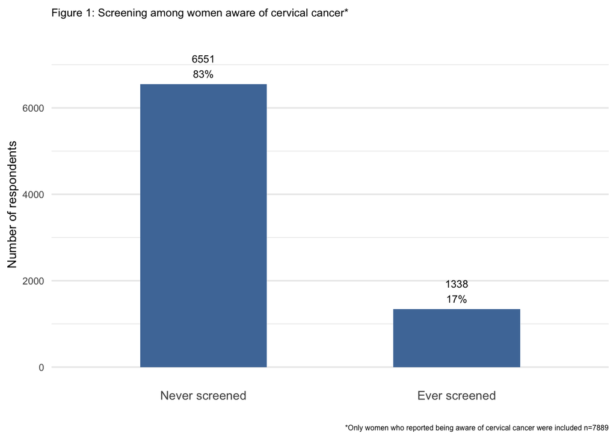

#### Characteristics of woman that heard about cervical cancer by screening status

Figure 2 examines the socio-demographic characteristics of women who reported having heard of cervical cancer but had never been screened vs the one that actually got screened. By focusing on residence, education level, and household wealth, this analysis highlights the groups in which awareness fails to translate into preventive action.

Screening uptake was higher among women living in urban areas (68% vs 47%) and among those with higher education (20% vs 8%). Socioeconomic differences were particularly pronounced: women in the richer and richest wealth groups comprised 79% of those ever screened, compared with 56% of women who were never screened. Together, these patterns indicate strong socioeconomic and geographic inequalities in access to cervical cancer screening; women who were ever screened were substantially more urban, wealthier, and better educated than women who were never screened.

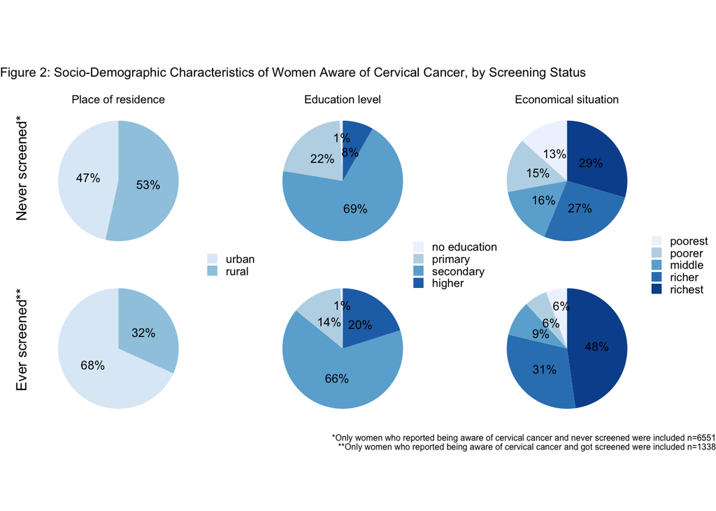

#### Time since last cervical cancer screening

Having established the socio-demographic inequalities associated with ever being screened (Figure 2), Figure 3 examines how recently screening occurred among women who reported prior screening, offering a partial view of continuity in preventive care. Half of these women (50%) reported being screened within the past year, while 38% had been screened 1–5 years ago and 12% had not been screened for more than five years. Although recent screening is common among those who have ever accessed services, a notable proportion appear not to be screened within recommended intervals.

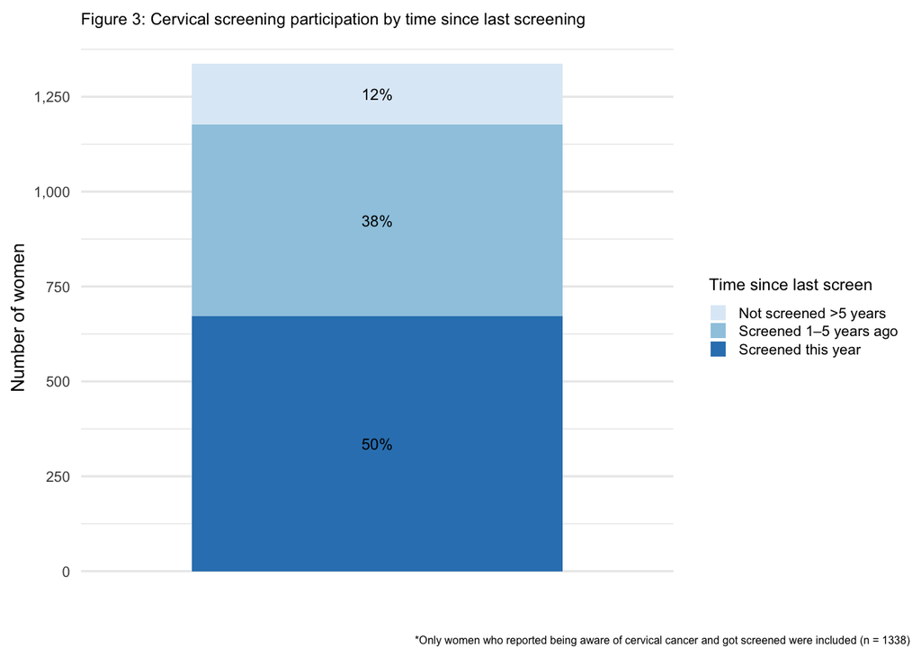

#### Cervical cancer screening by age group

While Figure 3 describes overall screening recency among women who have ever been screened, Figure 4 disaggregates these patterns by age group to examine how screening recency varies across the life course.

The figure hilights clear age differences in screening recency. Women screened in the past year were predominantly aged 25–44, while women aged 45–54 were overrepresented among those whose last screening occurred more than five years ago. This pattern is relevant in light of WHO recommendations, which advise regular cervical cancer screening for women aged 30–49 years (or starting earlier depending on national guidelines), with repeat screening at defined intervals depending on the method used (WHO Global Screening Strategy for Cervical Cancer Elimination). Importantly, these findings must be interpreted with caution. The DHS captures only time since the most recent screening, not lifetime screening history or screening regularity. For example, a woman screened in the past year may not have been screened for many years prior, while another screened 3–5 years ago may have previously adhered to regular screening intervals. As such, these results reflect recency of last screening rather than adherence to recommended screening schedules, limiting conclusions about long-term screening behavior.

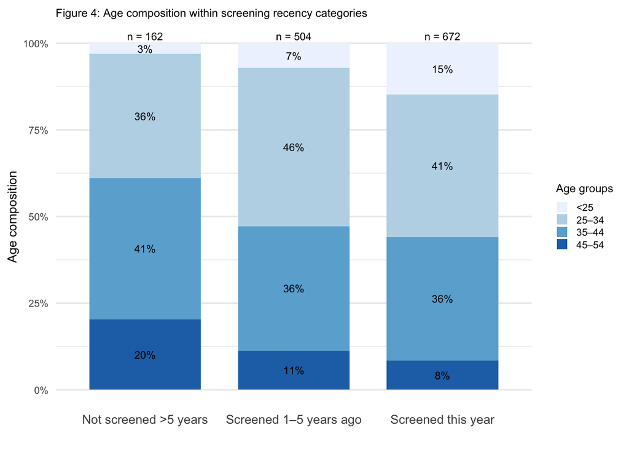

## Conclusions

Cervical cancer awareness among women in Zimbabwe is relatively high, with nearly four in five women reporting that they have heard of the disease. However, this awareness does not translate into widespread screening participation. Among women who were aware of cervical cancer, fewer than one in five reported ever having been screened. Screening uptake was strongly patterned by socioeconomic and geographic factors: women who were urban, wealthier, and more educated were substantially more likely to report prior screening than their rural, poorer, and less educated counterparts.

Among women who had ever been screened, most reported recent screening, particularly those aged 25–44 years, suggesting that once access to screening services is established, continued engagement may be more likely. Taken together, these findings indicate a marked disconnect between knowledge of cervical cancer and engagement in preventive screening. Targeted efforts to improve access and reduce structural barriers—especially for rural and socioeconomically disadvantaged women—will be essential to advance progress toward the WHO cervical cancer elimination goals, particularly in settings where screening access remains uneven.

## Limitations

This analysis relies on self-reported data, which may be affected by recall and social desirability bias. Screening indicators do not capture the method, quality, or adherence to recommended screening intervals, and time since last screening reflects recency rather than regular participation. Finally, the cross-sectional design of the DHS precludes causal interpretation of the observed associations.